# Social Behaviour Dynamics: Week 2

Noémi Schuurman, based on materials of Ellen Hamaker

February 2022

In this lab we follow the analyses discussed in the paper by Schafer and Kang (2008) that are used to estimate causal effects and control for confounders. There are nine techniques they cover; below, all of them will be included, but note that some of them are optional (they are included for the sake of completeness, but they are not exam material).

We will also use the data from Schafer and Kang, which are in the data file called SchaferKangData.dat. These are simulated data, and hence the authors (and we) know what the correct answer to the question ``What is the effect of dieting on emotional distress?’’ actually is. Hence, the purpose of the exercises here is to obtain a deeper understanding and hands-on experience with the diverse techniques.

Make sure to compare the results you get throughout the exercises to those reported in Table 6 in Schafer and Kang. For null hypothesis tests, you can use a significance level of 0.05 throughout.

## 1. Data and R-packages

In this practical you will make use of various R-packages. If you haven’t already, install the following packages:

```r
# install.packages("tableone")
# install.packages("MatchIt")
# install.packages("survey")
```

Load the data, which are in the datafile called SchaferKangData.dat. Take a look at the data set. See Table 3 in Schafer and Kang for a description of the variables.

```r
df <- read.table("SchaferKangData.dat", header=T)
df[1:10,]
```

```
##    DISTR.1 BLACK NBHISP GRADE SLFHLTH SLFWGHT WORKHARD GOODQUAL PHYSFIT PROUD
## 1     0.47     0      0    10       4       4        2        2       2     2
## 2     0.05     0      0     8       2       3        1        1       2     1
## 3     0.63     0      0     8       2       3        2        2       2     2
## 4     0.16     1      0     9       1       4        2        1       2     1
## 5     1.79     1      0     9       4       4        1        2       2     2
## 6     0.32     0      0    10       1       3        1        1       2     1
## 7     1.11     0      0    10       2       3        1        1       2     1
## 8     0.32     0      0     9       3       4        2        1       3     2
## 9     0.26     0      0    10       1       4        2        2       2     2
## 10    0.89     1      0    10       2       2        2        2       1     1
##    LIKESLF ACCEPTED FEELLOVD DIET DISTR.2
## 1        5        2        2    1    0.40
## 2        1        2        1    1    0.09
## 3        3        2        2    0    0.69
## 4        2        2        1    1    0.08
## 5        3        3        2    0    1.41
## 6        4        1        1    0    0.52
## 7        2        2        2    0    1.32
## 8        2        3        3    0    0.29
## 9        1        3        2    0    0.43
## 10       1        1        1    0    1.76
```

$~$

## 2. Prima Facie Effect: Not controlling for any variable.

When a randomized controlled trial (RCT) has been conducted, the treatment groups should not differ on any (pre-treatment) covariate due to random assignment. In that case, the ACE can be computed by taking the difference in means between the two groups for the outcome variable (not controlling for any variable). This is also referred to as the *prima facie effect*.

### 2.1 Method 1: *Compare means*

Although the current data are not generated by a RCT scenario, we will nevertheless consider this naive estimation approach for the causal effect.

$\blacktriangleright$ Compare the means between the groups on the outcome variable (see Equation (5) in S&K; use for instance `t.test()` in R).

```r
t.test1 <- t.test(DISTR.2 ~ DIET, df)
# Difference in means between the groups:
m1 <- t.test1$estimate[2]
m0 <- t.test1$estimate[1]
m1 - m0 #Note: the result of this command may carry on the header "mean for group 1", but it really is the difference in means.
```

```
## mean in group 1
##      0.05961424
```

```r
# Standard error
t.test1$stderr
```

```
## [1] 0.01533978
```

```r
# p-value
t.test1$p.value
```

```
## [1] 0.0001054363
```

### 2.2 Investigating covariates - potential confounding

The mean difference above is based on the assumption that there is no confounding, so we can simply take that difference to estimate the mean causal effect. However, we have a set of observed covariates, and if our data mimic a true RCT, there should be no mean differences between the two groups on these covariates. We can evaluate this, for example, with the *standardized mean difference* , that is:

$$\Delta Z = \frac{(\bar{Z}|X=1) -(\bar{Z}|X=0)} {\sqrt{((S^2|X=1) + (S^2|X=0))/2}}$$

where

- $\bar{Z}|X=x$ is the mean on covariate $Z$ in group $x$
- $S^2|X=x$ is the variance in group $x$
- $X=1$ is the diet group; $X=0$ is the non-diet group

The standardized mean difference is an effect size measure to evaluate how large a difference is between two means, and is also referred to in the literature as ‘Cohen’s d’. Of course, one could consider other ways of evaluating practically important differences between group means, we’ll use the SMD here to get the main idea. For this purpose, use a cut-off of 0.1 to indicate whether the difference is concerning or not.

$\blacktriangleright$ Determine the standardized mean difference between the girls who did diet versus the girls who did not diet on the first covariate, that is: DISTR.1 (emotional distress at wave 1).

```r
df1 <- df[ which(df$DIET == 1), ]
df0 <- df[ which(df$DIET == 0), ]

(mean(df1$DISTR.1) - mean(df0$DISTR.1))/(sqrt( (var(df1$DISTR.1)+var(df0$DISTR.1))/2 ))
```

```
## [1] 0.2142174
```

$\blacktriangleright$ Instead of computing these standardized mean differences yourself, you can also use the function `CreateTableOne()` from the package `tableone`. Run the code below.

```r
library(tableone)
table1 <- CreateTableOne(vars=c("DISTR.1","BLACK", "NBHISP", "GRADE",
                      "SLFHLTH", "SLFWGHT", "WORKHARD", "GOODQUAL",
                          "PHYSFIT", "PROUD", "LIKESLF", "ACCEPTED",
                      "FEELLOVD"), strata="DIET", data=df,
                        test=FALSE)
```

$\blacktriangleright$ Obtain the table with standardize mean differences using `print(table1, smd=TRUE)`, and comment on the results.

$~$

## 3 Controlling for Confounders Z: Model the relation of $Z$ with $Y$

Schafer and Kang describe three techniques to control for confounders $Z$, that in some way using these confounders as predictors for the outcome variable $Y$:

- *ANCOVA* (which is what they call linear regression with no interactions between predictors)
- *regression* (which is what they call linear regression with interactions between predictors)
- *regression estimation*, which is based on estimating the potential outcomes $Y_i^0$ and $Y_i^1$ for each participant based on the covariates

We will include all the covariates in our analyses below, even if they had a small standardized mean difference in the previous exercise. This to align with Schafer & Kang, although it may be less important to control for these covariates. Furthermore, although there may not be a need to correct for all covariates, they may still account for variance in the outcome variable, and by accounting for this, we increase the power of our analysis. Do keep in mind that here, we assume we are sure that all of these covariates are potential confounders and hence something to control for. In practice we are often not so sure about this. Related to this, remember what we learned last week: In general we do not want to just control for all covariates we have - controlling accidentaly for mediator or collider variables could mess up our estimates of causal effects!

### 3.1 Method 2: *ANCOVA* (Linear Regression without Interactions)

To run an ANCOVA as described in S&K, we can simply run a regression model *without interactions* between the predictors (see Equation (6) in S&K). Our model here can be written as:

$$DISTR.2_{i} = \alpha + \theta DIET_i + \beta_1 DISTR.1_i + \beta_2 BLACK_i + \beta_3 NBHISP_i$$

$$+ \beta_4 GRADE_i+ \beta_5 SLFHLTH_i + \beta_6 SLFWGHT_i + \beta_7 WORKSHARD_i$$
$$+ \beta_8 GOODQUAL_i + \beta_9 PHYSFIT_i + \beta_{10} PROUD_i$$
$$+ \beta_{11} LIKESLF_i + \beta_{12} ACCEPTED_i + \beta_{13}FEELLOVED_i + e_i$$

Note: All our categorical variables are dichotomous (dummy-coded) variables, so we included them in the same way as the continuous variables. Keep in mind that for categorical predictor variables with more than 2 categories, it is prudent to make dummies. This can be done by including the categorical predictors as a factor variable, in which case dummies are made during the (g)lm analysis in R; alternatively, one would oneself create dummy variables for the various categories, and include those dummies as predictors in the regression model.

$\blacktriangleright$ Run the ANCOVA model (for instance using the function `glm()` in R), and interpret the results.

```r
M2 <- glm(DISTR.2 ~ DIET    + DISTR.1 + BLACK + NBHISP
    + GRADE + SLFHLTH + SLFWGHT + WORKHARD + GOODQUAL
        + PHYSFIT + PROUD + LIKESLF + ACCEPTED + FEELLOVD,
        data=df)
summary(M2)
```

```
##
## Call:
## glm(formula = DISTR.2 ~ DIET + DISTR.1 + BLACK + NBHISP + GRADE +
##     SLFHLTH + SLFWGHT + WORKHARD + GOODQUAL + PHYSFIT + PROUD +
##     LIKESLF + ACCEPTED + FEELLOVD, data = df)
##
## Deviance Residuals:
##      Min        1Q    Median        3Q       Max
## -1.69102  -0.22781  -0.05734   0.18025   1.81213
##
## Coefficients:
##               Estimate Std. Error t value Pr(>|t|)
## (Intercept) -0.0052087  0.0422214  -0.123 0.901821
## DIET        -0.0136658  0.0129321  -1.057 0.290675
## DISTR.1      0.5178247  0.0125785  41.168  < 2e-16 ***
## BLACK        0.0745764  0.0120532   6.187 6.53e-10 ***
## NBHISP       0.0289905  0.0141752   2.045 0.040884 *
## GRADE        0.0019352  0.0035672   0.543 0.587490
## SLFHLTH      0.0196974  0.0059809   3.293 0.000996 ***
## SLFWGHT      0.0038613  0.0069990   0.552 0.581183
## WORKHARD    -0.0121711  0.0056656  -2.148 0.031734 *
## GOODQUAL     0.0209810  0.0098513   2.130 0.033231 *
## PHYSFIT     -0.0005642  0.0069283  -0.081 0.935099
## PROUD        0.0376379  0.0101757   3.699 0.000219 ***
## LIKESLF      0.0242944  0.0064040   3.794 0.000150 ***
## ACCEPTED     0.0167152  0.0068032   2.457 0.014040 *
## FEELLOVD     0.0389178  0.0085254   4.565 5.10e-06 ***
## ---
## Signif. codes:  0 '***' 0.001 '**' 0.01 '*' 0.05 '.' 0.1 ' ' 1
##
## (Dispersion parameter for gaussian family taken to be 0.1412421)
##
##     Null deviance: 1303.09  on 5999  degrees of freedom
## Residual deviance:  845.33  on 5985  degrees of freedom
## AIC: 5300.6
##
## Number of Fisher Scoring iterations: 2
```

### 3.2 Method 3: *Regression* (Linear Regression with extras such as interactions)

We can extend the ANCOVA model above by incorporating various product terms between the predictors:

- product between covariate and itself: *quadratic effect*
- product/interaction between two covariates: *interaction*
- product/interaction between treatment and covariates: *non-parallel planes* (see Figure 2 in Schafer and Kang)

Schafer and Kang consider the latter option in their paper.

- Note: Before including interactions, one needs to center the covariates, and the interaction term is build up out of these centered covariates. This to ensure the interpretation we want for the main effects: Centering makes the mean of a variable equal to zero. Further, remember that an interaction effect indicates that the effect of one variable on the outcome differs depending on the value of another variable. The interpretation of main effects is ‘the effect of this variable on the outcome if the other variables are zero’. Hence, not centering the variables means that the main effect for treatment is the (causal) effect when the other variables are zero, which may not represent the *average* causal effect of treatment. If we center, the main effect is the (causal) effect when the other variables take on their mean value, hence we do get the *average* causal effect.
- Note: Importantly, if there are interactions with treatment, that would imply that there are differently sized causal effects depending on the value of other variables.

$\blacktriangleright$ Run the regression model with two-way interactions between the treatment variable and the covariates, for instance using the function `glm()` in R, and interpret the results.

### 3.3 Method 4: *Regression estimation* (Don’t confuse with the Regression Methods 2&3…)

The method of ’Regression estimation` discussed by S&K is *not* the same as regular regression analysis with control variables (the methods discussed in the two previous exercises). In regression estimation, we make actual *predictions of the potential outcomes that were not observed*, and use these to compute the causal effect of interest.

To use regression estimation (see Equation (15) in S&K), you have to:

- divide the data set into those who were treated and those who were not treated
- estimate a regression model (with all the covariates) in each group separately
- obtain the parameter estimates from each group (see Equations (13) and (14) in S&K)
- use these and the covariates to predict the potential outcomes $\hat{Y}_i^0$ and $\hat{Y}_i^1$
- compute the average difference between these *predicted* potential outcomes

Hence, this approach is a technique to impute the missing values in the data file that only contains the potential outcomes that were observed.

*Note that it is not as straightforward as it may seem to obtain appropriate standard errors/certainty intervals/p-values for this mean difference: While you could run a paired t-test, and obtain some, those do not take into account that the potential outcomes are actually estimated rather than observed. We will ignore this here.

$\blacktriangleright$ Start with creating separate data sets for the two treatment groups, and running a regression analysis for each group separately:

```r
df1 <- subset(df, DIET==1)
df0 <- subset(df, DIET==0)

# Regression analysis with only people with X=1:
M3.1 <- glm(DISTR.2 ~ + DISTR.1 + as.factor(BLACK) + as.factor(NBHISP)
            + GRADE + SLFHLTH + SLFWGHT + WORKHARD + GOODQUAL
                + PHYSFIT + PROUD + LIKESLF + ACCEPTED + FEELLOVD,
                data=df1)

# Regression analysis with only people with X=0:
M3.0 <- glm(DISTR.2 ~ + DISTR.1 + as.factor(BLACK) + as.factor(NBHISP)
            + GRADE + SLFHLTH + SLFWGHT + WORKHARD + GOODQUAL
              + PHYSFIT + PROUD + LIKESLF + ACCEPTED + FEELLOVD,
                data=df0)
```

$\blacktriangleright$ Now, obtain estimates for everyone (both for those who we observed $X=1$ and $X=0$) for the potential outcome under treatment (i.e., $\hat{Y}^1_i$) and under no treatment (i.e., $\hat{Y}^1_i$):

```r
# Obtain a prediction for the outcome using all the cases, based on
# the parameter estimates obtained above and saved in M3.1:
M3.est.Y1 <- predict(M3.1, newdata = df)

# Do the same, but now with the parameters saved in M3.0:
M3.est.Y0 <- predict(M3.0, newdata = df)
```

$\blacktriangleright$ Estimate the average causal effect based on what you have created in the previous (focus on obtaining the point estimate, you do not need to obtain a correct standard error/certainty interval/pvalue).

```r
# Look at the predicted potential outcomes
cbind(M3.est.Y0, M3.est.Y1)[1:10,]
```

```
##         [,1]      [,2]
## 1  0.6798196 0.6563903
## 2  0.2418481 0.1672951
## 3  0.6594521 0.6728799
## 4  0.3555863 0.3584581
## 5  1.4298966 1.3315301
## 6  0.4128621 0.3974892
## 7  0.8623319 0.7773935
## 8  0.5531470 0.4660255
## 9  0.4186977 0.4506349
## 10 0.7299912 0.7454811
```

```r
# Estimate the causal effect now, using a t-test
t.test(M3.est.Y0, M3.est.Y1, paired = TRUE, alternative = "two.sided")
```

```
##
##  Paired t-test
##
## data:  M3.est.Y0 and M3.est.Y1
## t = 8.2764, df = 5999, p-value < 2.2e-16
## alternative hypothesis: true difference in means is not equal to 0
## 95 percent confidence interval:
##  0.004470006 0.007244792
## sample estimates:
## mean of the differences
##             0.005857399
```

$\blacktriangleright$ **(OPTIONAL)** Above we have used the predicted potential outcomes for everyone. However, one of them is actually observed, and we could use those instead of the predicted potential outcome (i.e., we use the observed fact, and predict only the counterfact). Hence, for individuals in the no treatment condition you use $Y_i$ instead of $\hat{Y}_i^0$, and for those in the treatment condition you use $Y_i$ instead of $\hat{Y}_i^1$ (this is also described around Equation (16) in S&K). Check whether this leads to a different result.

```r
# Take the predicted potential outcome for X=0
# and only for those for whom we observed X=0
# do we overwrite the predicted potential outcome
M3b.Y0 <- M3.est.Y0
M3b.Y0[df$DIET==0] <- df$DISTR.2[df$DIET==0]

# Do the same for the predicted potential outcome for X=1
M3b.Y1 <- M3.est.Y1
M3b.Y1[df$DIET==1] <- df$DISTR.2[df$DIET==1]

# Now do the t-test with these (observed and predicted) potential outcomes:
t.test(M3b.Y0, M3b.Y1, paired = TRUE, alternative = "two.sided")
```

```
##
##  Paired t-test
##
## data:  M3b.Y0 and M3b.Y1
## t = 1.1979, df = 5999, p-value = 0.231
## alternative hypothesis: true difference in means is not equal to 0
## 95 percent confidence interval:
##  -0.003728044  0.015442842
## sample estimates:
## mean of the differences
##             0.005857399
```

### 3.4 Conclusion

In the methods discussed so far, we rely on extrapolation, which could be a problem. For example, it could happen that we have to extrapolate (e.g., predict potential outcomes) for the treated group based on the untreated group, while these groups have quite different values for their covariates. If so, we can have a lot of uncertainty about whether the parameters based on the untreated group are suitable for our treated group. The fact that we are assuming linear relations in all of the above may make this especially problematic.

$\blacktriangleright$ To get a first impression of whether this extrapolation issue applies here, use *standardized mean differences* again. In this case, use cut off of 0.3 to indicate a potential problem.

$~$

## 4 Controlling for Confounders Z: Model the relation of $Z$ with $X$

Above, we included the covariates as predictors of the outcome in various ways. As discussed above, these approaches can be problematic, for example due to problems with the linear extrapolations we are making.

There are various alternative techniques that are all based on using *propensity scores*: This is an individual’s probability of treatment based on their scores on the covariates (i.e., $P(X=1|Z=Z_i)$. If we know how likely a person was to receive treatment, we can use this information to mimic a randomized controlled trial (in which everyone has the same probability of receiving treatment). Schafer and Kang consider three common techniques for this:

- *matching*, in which we try to create pairs of a treated and an untreated individual that have the same propensity score
- *inverse probability weighting*, in which we create a pseudo-population that is balanced on the covariates
- *subclassification or stratification*, in which we create strata in which there are no (meaningful) differences in the covariates left

### 4.1 Estimate the propensity scores

We will start with estimating a propensity score for each person in the data set. This score will then be used in the diverse techniques that follow.

$\blacktriangleright$ To compute a propensity score, run a logistic regression model in which the treatment variable X (which has values 0 and 1) is the outcome variable, and the covariates are the predictors. Make sure to save the probability for each person for scoring 1 on $X$ (here: DIET). You can use the `glm` function from the `stats` package for this.

```r
# Run the logistic regression analysis
logreg <- glm(DIET ~ DISTR.1 + as.factor(BLACK) + as.factor(NBHISP)
                    + GRADE + SLFHLTH + SLFWGHT + WORKHARD + GOODQUAL
                        + PHYSFIT + PROUD + LIKESLF + ACCEPTED + FEELLOVD,
                    family = binomial(), data = df)

# Obtain a prediction of the probability of treatment (i.e., DIET=1)
ps <- predict(logreg, type = "response")

# Add this predicted probability to the datafile
df$ps <- ps

# Look at the datafile
round(df[1:10,], 2)
```

```
##    DISTR.1 BLACK NBHISP GRADE SLFHLTH SLFWGHT WORKHARD GOODQUAL PHYSFIT PROUD
## 1     0.47     0      0    10       4       4        2        2       2     2
## 2     0.05     0      0     8       2       3        1        1       2     1
## 3     0.63     0      0     8       2       3        2        2       2     2
## 4     0.16     1      0     9       1       4        2        1       2     1
## 5     1.79     1      0     9       4       4        1        2       2     2
## 6     0.32     0      0    10       1       3        1        1       2     1
## 7     1.11     0      0    10       2       3        1        1       2     1
## 8     0.32     0      0     9       3       4        2        1       3     2
## 9     0.26     0      0    10       1       4        2        2       2     2
## 10    0.89     1      0    10       2       2        2        2       1     1
##    LIKESLF ACCEPTED FEELLOVD DIET DISTR.2   ps
## 1        5        2        2    1    0.40 0.50
## 2        1        2        1    1    0.09 0.10
## 3        3        2        2    0    0.69 0.15
## 4        2        2        1    1    0.08 0.23
## 5        3        3        2    0    1.41 0.32
## 6        4        1        1    0    0.52 0.28
## 7        2        2        2    0    1.32 0.21
## 8        2        3        3    0    0.29 0.32
## 9        1        3        2    0    0.43 0.24
## 10       1        1        1    0    1.76 0.02
```

```r
# The last column in the datafile now contains the predicted
# probability of being treated, based on the covariates.
```

Now that we have the propensity scores, we should first consider the distribution of propensity scores in each of the treatment groups separately, to determine whether there is overlap between the propensity scores of the two groups.

$\blacktriangleright$ Make a plot that includes a histogram for the propensities of the treated, and a histogram for the propensity scores of the untreated to evaluate this. Discuss what you see in the plot, and what this may imply for our causal inferences.

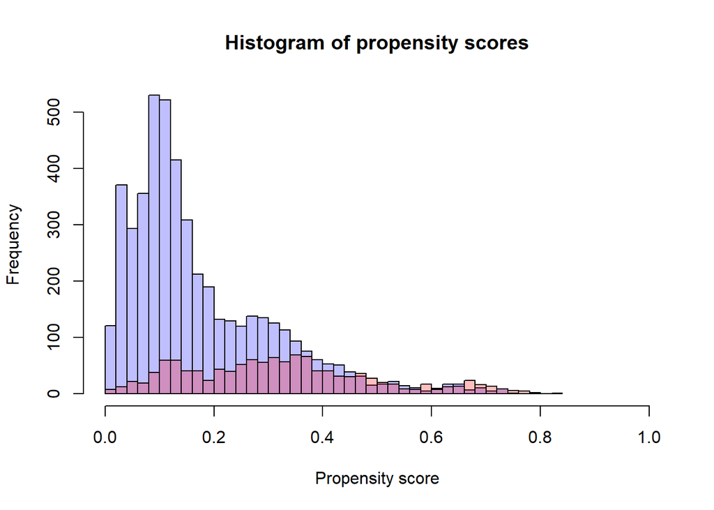

```r
# Create separate data files (which now include the propensity scores)
# for those treated and those not treated:
df1 <- df[ which(df$DIET == 1), ]
df0 <- df[ which(df$DIET == 0), ]

# Create histograms, then plot one and add the other:
hist0 <- hist(df0$ps, breaks=30, plot=FALSE)
hist1 <- hist(df1$ps, breaks=30, plot=FALSE)
plot( hist0, col=rgb(0,0,1,1/4), xlim=c(0,1),
        xlab="Propensity score",
      main="Histogram of propensity scores")
plot( hist1, col=rgb(1,0,0,1/4), xlim=c(0,1), add=T)
```

Now that we have determined the propensity scores and their distributions for the the treated and the non-treated overlap well, we can make use of these scores within different techniques.

### 4.2 Method 4: *Matching*

Matching based on the propensity scores is the first technique in this category that we consider. It is based on finding people in the both treatment groups that have similar propensity scores: The idea is that these individuals are comparable on the entire set of covariates, and can thus be considered randomly assigned to the two condition.

In practice, this is done by taking a person from the smallest of the two groups (here the group for which DIET=1, the treated), and finding a person in the other group that is most like this person in terms of their propensity score. We can do this using the function `matchit()` from the package `MatchIt` in R. Please note that this will give us slightly different results than those obtained by S&K.

To run the matching function, we plug in the same expression as we used when we obtained the propensity scores ourselves, and use the method “nearest” (Check out the helpfil of function `matchit` to get an impression of what it does):

```r
library(MatchIt)
matchdat <- matchit(DIET ~ DISTR.1 + as.factor(BLACK) + as.factor(NBHISP)
            + GRADE + SLFHLTH + SLFWGHT + WORKHARD + GOODQUAL
            + PHYSFIT + PROUD + LIKESLF + ACCEPTED + FEELLOVD,
        method = "nearest",  data = df)
```

$\blacktriangleright$ Describe/Interpret the information that is reported in the output (matchdat).

$\blacktriangleright$ There are two useful plotting options regarding the propensity scores of our matched pairs: `plot(matchdat,type="jitter")` and `plot(matchdat,type="hist")`. Get both plots, and describe what they represent.

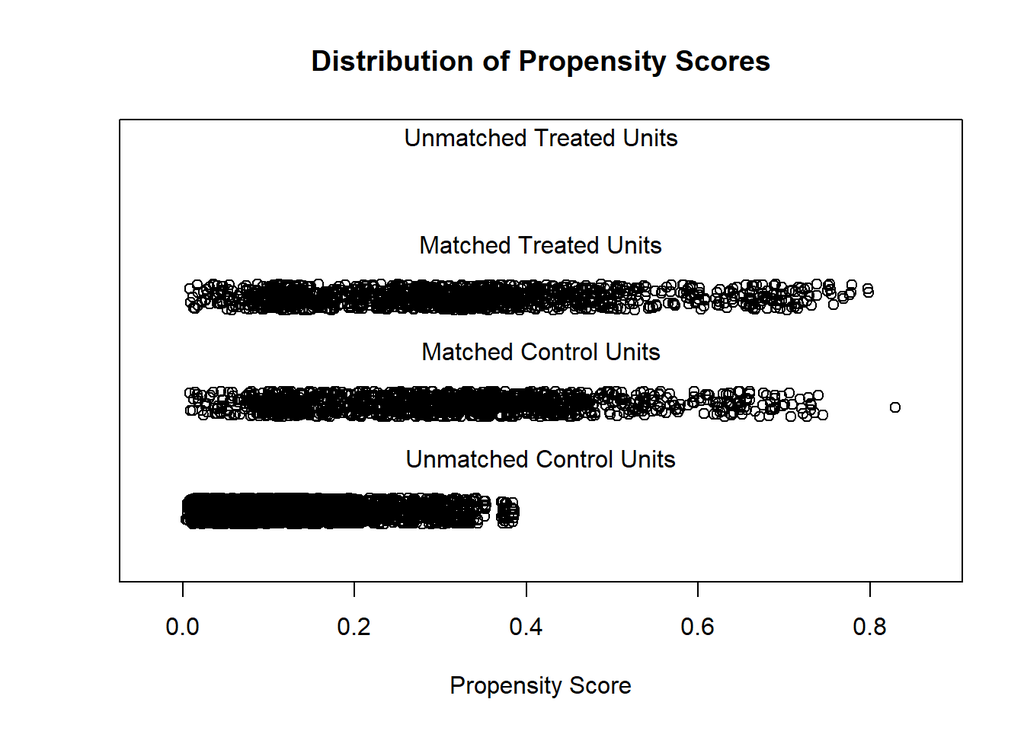

```
## [1] "To identify the units, use first mouse button; to stop, use second."
```

```
## integer(0)
```

```r
plot(matchdat,type="jitter")
```

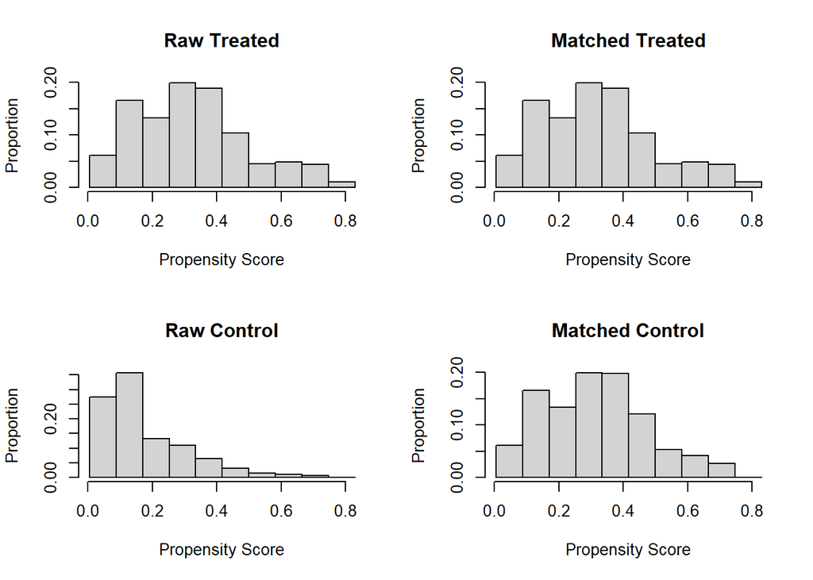

```r
plot(matchdat,type="hist")
```

$\blacktriangleright$ To do the analysis on the matched cases only, we need to create a new data file with only the matched cases, using: `df.match <- match.data(matchdat)`. Create the Table 1 for this matched data set. What can you conclude?

```r
# To extract the new datafile from the original one:
df.match <- match.data(matchdat)

# Create Table 1:
table1 <- CreateTableOne(vars=c("DISTR.1","BLACK", "NBHISP", "GRADE",
                      "SLFHLTH", "SLFWGHT", "WORKHARD", "GOODQUAL",
                          "PHYSFIT", "PROUD", "LIKESLF", "ACCEPTED",
                      "FEELLOVD"), strata="DIET", data=df.match,
                        test=FALSE)
print(table1, smd=TRUE)
```

```
##                       Stratified by DIET
##                        0           1           SMD
##   n                    1220        1220
##   DISTR.1 (mean (SD))  0.71 (0.45) 0.71 (0.45)  0.007
##   BLACK (mean (SD))    0.18 (0.38) 0.17 (0.38)  0.004
##   NBHISP (mean (SD))   0.16 (0.36) 0.15 (0.36)  0.007
##   GRADE (mean (SD))    9.37 (1.35) 9.37 (1.34)  0.002
##   SLFHLTH (mean (SD))  2.36 (0.95) 2.35 (0.91)  0.011
##   SLFWGHT (mean (SD))  3.82 (0.69) 3.84 (0.70)  0.033
##   WORKHARD (mean (SD)) 2.07 (0.86) 2.05 (0.85)  0.022
##   GOODQUAL (mean (SD)) 1.81 (0.65) 1.84 (0.71)  0.049
##   PHYSFIT (mean (SD))  2.53 (0.97) 2.53 (0.93)  0.007
##   PROUD (mean (SD))    1.85 (0.77) 1.86 (0.79)  0.011
##   LIKESLF (mean (SD))  2.46 (1.05) 2.52 (1.06)  0.057
##   ACCEPTED (mean (SD)) 2.33 (1.03) 2.35 (1.06)  0.023
##   FEELLOVD (mean (SD)) 1.92 (0.87) 1.93 (0.90)  0.010
```

$\blacktriangleright$ Subsequently, investigate with a t-test whether the means on the outcome variable DISTR.2 differ among the matched cases.

```r
# Do a t-test on the matched data file:
t.test2 <- t.test(DISTR.2 ~ DIET, df.match)
t.test2
```

```
##
##  Welch Two Sample t-test
##
## data:  DISTR.2 by DIET
## t = 1.1383, df = 2438, p-value = 0.2551
## alternative hypothesis: true difference in means between group 0 and group 1 is not equal to 0
## 95 percent confidence interval:
##  -0.01603559  0.06041264
## sample estimates:
## mean in group 0 mean in group 1
##       0.7253279       0.7031393
```

```r
# Note the means per group are included at the bottom.
# We can also compute the mean difference, using:
t.test2$estimate[2] - t.test2$estimate[1]
```

```
## mean in group 1
##     -0.02218852
```

$\blacktriangleright$ Compare this result to the mean comparison you did at the start; explain why the mean differences that you have just determined is an estimate of the ACE1 rather than of the ACE.

### 4.3 Method 5: *IPW*

We can also use inverse probability weighting (IPW). In this case, the estimated propensity scores $\hat{\pi}_i$ are used to determine the probability that an individual would have received the treatment that they received:

- for the treated ($X_i=1$) this is simply $\hat{\pi}_i$
- for the non-treated ($X_i=0$) this is $1-\hat{\pi}_i$.

Next, we use these probabilities as weights, by taking their inverse: That way, a case that received a treatment that she was very likely to receive, will get a small weight, while a case that received a treatment that she was very unlikely to receive, will get a large weight. Thus, the inverse probability weight indicates the number of persons from the population that this person represents. For the treated, this weight is $1/\hat{\pi}_i$; for the untreated, it is $1/(1-\hat{\pi}_i)$.

$\blacktriangleright$ Compute the ACE using this IPW (see Equation (20) in S&K).

```r
Y <- df$DISTR.2
X <- df$DIET
mu1hat <- sum( X*Y/ps ) / sum(X/ps)
mu0hat <- sum( (1-X)*Y/(1-ps) ) / sum((1-X)/(1-ps))
mu1hat - mu0hat
```

```
## [1] -0.005064163
```

### 4.4 Method 6: *Subclassificiation*

Subclassification, also known as stratification, is a method that consists of creating classes (strata) based on the propensity scores. The idea is that the individuals within each stratum are rather similar with respect to their propensity score, and thus with respect to the entire set of covariates on which the propensity score is based; if the covariates are well balanced within each stratum, this is a way to mimic an RCT within each stratum. By subsequently estimating the ACE in each stratum (using a mean comparison such as Method 1, or an ANCOVA or regression analysis such as Method 2), we can determine the causal effect for individuals who are similar with regard to the entire set of covariates (as these are used to determine the propensity scores).

$\blacktriangleright$ Begin with creating five strata based on the propensity scores (for instance, use the function cut() in R); each stratum should contain 20% of the (total number of) observations.

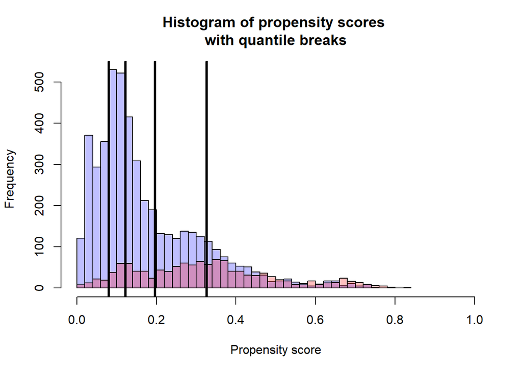

```r
df$stratum <- cut(df$ps,
                    breaks=c(quantile(df$ps, probs=seq(0,1,0.2))),
                    labels=seq(1:5),
                    include.lowest=TRUE)

# We can also make a plot of these quantiles; this is based on
# using the same histrogram we had before, now adding vertical
# lines for where the breaks of the strat are.

plot( hist0, col=rgb(0,0,1,1/4), xlim=c(0,1),
    xlab="Propensity score", main="Histogram of propensity scores \nwith quantile breaks")
plot( hist1, col=rgb(1,0,0,1/4), xlim=c(0,1), add=T)

br <- c(quantile(df$ps, probs=seq(0,1,0.2)))

abline(v=br[2],col="black",lwd=3)
abline(v=br[3],col="black",lwd=3)
abline(v=br[4],col="black",lwd=3)
abline(v=br[5],col="black",lwd=3)
```

```r
# This shows that especially the fifth stratum is
# very wide (in the paper by Schafer and Kang they
# decide to further split the fourth stratum in two
# groups, and the fifth in four groups, because these
# are rather wide).

# We could also further investigate whether we need more strata
# by looking at the standardized mean differences in each stratum;
# these should be small, as the idea is that each stratum can be
# thought of as an RCT in which the assignment to treatment is
# random, and thus does not depend on any of the covariates.
```

$\blacktriangleright$ Next, compute the ACE in each stratum, taking the mean difference.

```r
# We perform a t-test in each stratum.

results <- matrix(,5,1)

for (quintiles in c(1:5)) {
  t.test3 <- t.test(DISTR.2 ~ DIET, data = df[which(df$stratum==quintiles),])
  print(t.test3)
  # Difference in means:
  results[quintiles,1] <- t.test3$estimate[2] - t.test3$estimate[1]
}
```

```
##
##  Welch Two Sample t-test
##
## data:  DISTR.2 by DIET
## t = -0.64615, df = 64.606, p-value = 0.5205
## alternative hypothesis: true difference in means between group 0 and group 1 is not equal to 0
## 95 percent confidence interval:
##  -0.18089062  0.09246131
## sample estimates:
## mean in group 0 mean in group 1
##       0.5672608       0.6114754
##
##
##  Welch Two Sample t-test
##
## data:  DISTR.2 by DIET
## t = -0.066853, df = 117.53, p-value = 0.9468
## alternative hypothesis: true difference in means between group 0 and group 1 is not equal to 0
## 95 percent confidence interval:
##  -0.10149097  0.09486247
## sample estimates:
## mean in group 0 mean in group 1
##       0.5812489       0.5845631
##
##
##  Welch Two Sample t-test
##
## data:  DISTR.2 by DIET
## t = -1.7668, df = 197.78, p-value = 0.0788
## alternative hypothesis: true difference in means between group 0 and group 1 is not equal to 0
## 95 percent confidence interval:
##  -0.15963403  0.00876165
## sample estimates:
## mean in group 0 mean in group 1
##       0.6600766       0.7355128
##
##
##  Welch Two Sample t-test
##
## data:  DISTR.2 by DIET
## t = 2.0353, df = 665.97, p-value = 0.04222
## alternative hypothesis: true difference in means between group 0 and group 1 is not equal to 0
## 95 percent confidence interval:
##  0.001992495 0.111069883
## sample estimates:
## mean in group 0 mean in group 1
##       0.6792056       0.6226744
##
##
##  Welch Two Sample t-test
##
## data:  DISTR.2 by DIET
## t = 1.2039, df = 1174.8, p-value = 0.2289
## alternative hypothesis: true difference in means between group 0 and group 1 is not equal to 0
## 95 percent confidence interval:
##  -0.02164432  0.09038353
## sample estimates:
## mean in group 0 mean in group 1
##       0.8102329       0.7758633
```

$\blacktriangleright$ Subsequently, you can compute the overall ACE by taking the average of the stratum-specific ACE’s (weighted by the stratum size).

### Conclusion

The three methods that we considered in this category are all based on using the propensity score, that is, the probability of being treated given the covariates. The goal of these techniques is to somehow mimic the situation we get in an RCT, where the probability of treatment is independent of the covariates. In matching, this is done by creating pairs of a treated and an untreated person who have (almost) identical propensity scores, resulting in a smaller but balanced dataset; in inverse probability weighting, this is done by weighing each person’s observation by their inverse probability of received treatment, thereby creating a balanced pseudo-population; and in subclassification this is done by creating strata based on the propensity scores such that within each stratum the covariates are balanced. In each approach, we should check whether it balances the covariates, for instance, by considering the standardized mean differences (for other options, see for instance: Austin, P. c. (2009). Balance diagnostics for comparing the distribution of baseline covariates between treatment groups in propensity-score matched samples. *Statistics in Medicine, 28*, 3093-3107. https://doi.org/10.1002/sim.3697).

$~$

## 5 Overall Conclusion

By now you probably see that the number of ways that we can account for covariate imbalance is about infinite. Ignoring the covariates (Method 1), is obviously not a good idea; hence, deciding which covariates to inlcude is a first important step, which we have discussed last week.

But even if we have decided which baseline covariates we need to account for, the options are almost limitless. In the ANCOVA and regression estimation procedures (Methods 2 and 3), we can add interactions and non-linear effects, for instance through using spline fitting. In all the other techniques that are based on propensity scores, we can also consider interactions and non-linear effects of covariates when predicting the log odds. Moreover, when using matching techniques (Method 4), we can choose to have more than one match per person, and we can choose between matching with or without replacement. In inverse probability weigthing (Method 5), we can decide to standardize the weights or not, and there are different ways to handle outliers. For subclassification (Method 6), we have to decide how many strata to create, and whether to further subdivide wide strata or not. The final category of techniques discussed by S&K that we did not cover (Methods 7, 8, and 9), is based on combinations of the other techniques, and therefor allow for even more researchers degrees of freedom.

To make matters worse, different methods and different choices may lead to different results and even different (substantive) conclusions, as we have also seen here. Unfortunately, there is no one method that always performs best under all circumstances. Hence, it is advisable to apply multiple methods to see whether the results are robust, or that they contradict each other. Ideally, one would combine different studies, and methods that rely on different assumptions to eventually get a clearer picture of what assumptions are problematic, and eventually of the true causal effect. This can never succeed if we are not open about our goals (e.g., do causal inference), and our assumptions and choices.

To make informed decisions on what to do—and what to avoid—under particular circumstances, it can be very helpful to check out simulation studies, such as the one by Schafer and Kang, or the more recent study by Goetghebeur, le Cessie, Stavola, Moodie and Waernbaum (2020. Formulating causal questions and principled statistical answers. *Statistics in Medicine, 39*, 4922-4948. https://doi.org/10.1002/sim.8741), or to perform a simulation study yourself to evaluate particular situations.

Finally, it is important to always keep in mind that all the techniques discussed here were developed under the assumption of no unobserved confounding. This means that all relevant confounders were assumed to be included as covariates. We also assumed only confounders were included, an no colliders/mediators, for example. Sensitivity analysis is a valuable approach to investigate how the effect of unobserved confounding can be further investigated (not covered in this course; for more information see for instance: Blackwell, M. (2013). A selection bias approach to sensitivity analysis for causal effects. *Political Analysis, 22*, 169-182. https://doi.org/10.1093/pan/mpt006).